# Travel Package Purchase Prediction

## Bivariate Analysis:

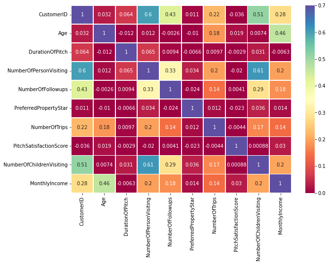

```python
corr= data_travel.corr()
plt.figure(figsize=(10,7))
sns.heatmap(corr,annot= True,vmin=0,vmax=0.7, cmap='Spectral',linewidths=0.75)
plt.show()
```

**Observations:**

**Let's analyse the dependent variable with all the numerical and categorical features and investigate possible relationships**

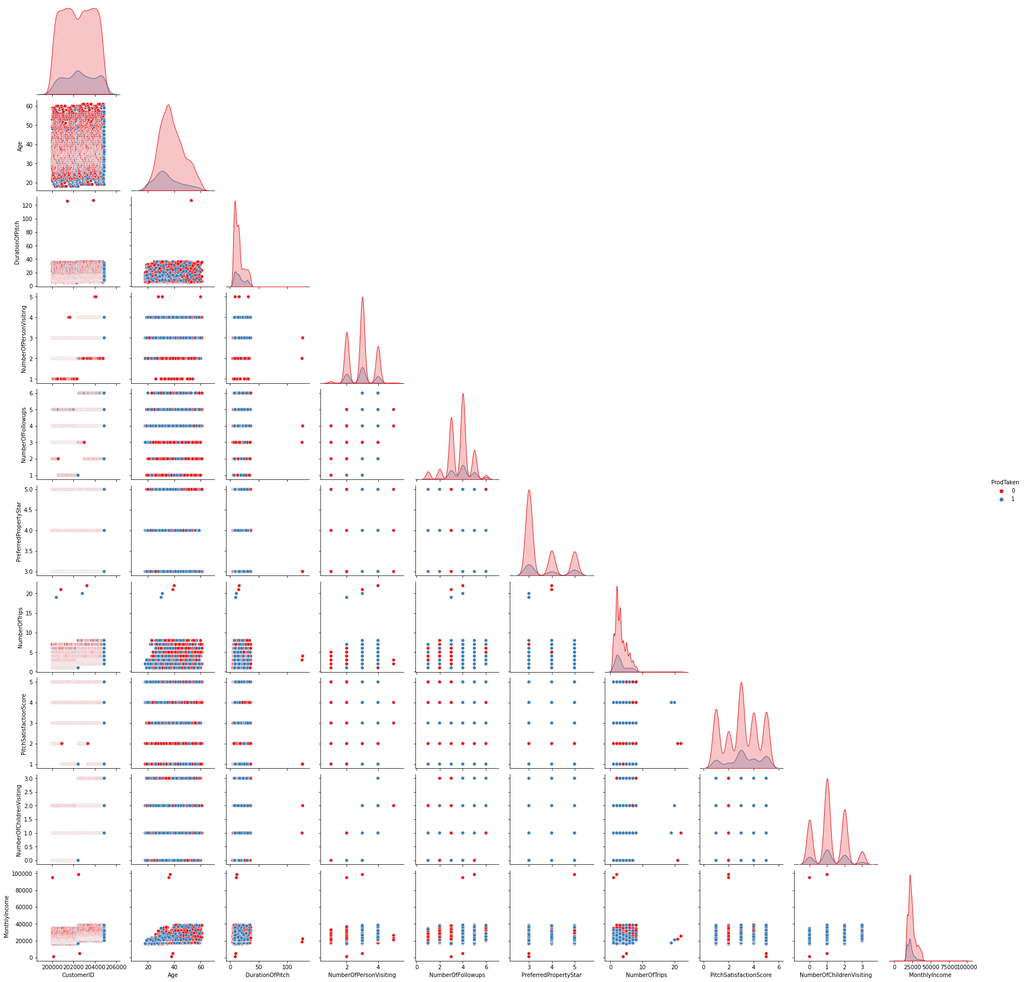

```python
sns.set_palette(sns.color_palette("Set1", 8))
sns.pairplot(data_travel, hue="ProdTaken",corner=True)
plt.show()
```

**Observations**

- Monthlyincome and Age has weak correlation
- Number of children visiting and number of person vsiting has correlation as expected.
- Numberof follow up and number of person vsiting has very weak correlation.

### TypeofContact VS ProdTaken

```python
#Stacked plot of categorical variables with Personal Loans
def stacked_plot(x):
    sns.set(palette='Dark2')
    tab1 = pd.crosstab(x,data_travel['ProdTaken'],margins=True)
    print(tab1)
    print('-'*120)
    tab = pd.crosstab(x,data_travel['ProdTaken'],normalize='index')
    tab.plot(kind='bar',stacked=True,figsize=(10,5))
    plt.legend(loc='lower left', frameon=True)
    plt.legend(loc="upper left", bbox_to_anchor=(1,1))
    plt.ylabel('Percentage')
    plt.show()
```

```
ProdTaken           0    1   All
TypeofContact
Company Invited  1109  310  1419
Self Enquiry     2837  607  3444
All              3946  917  4863
------------------------------------------------------------------------------------------------------------------------
```

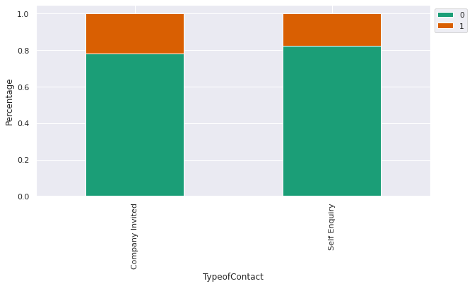

```python
stacked_plot(data_travel.TypeofContact)
```

- More Customers with CompanyInvited contact have bought Travel Packages

```
ProdTaken     0    1   All
CityTier
1          2670  520  3190
2           152   46   198
3          1146  354  1500
All        3968  920  4888
------------------------------------------------------------------------------------------------------------------------
```

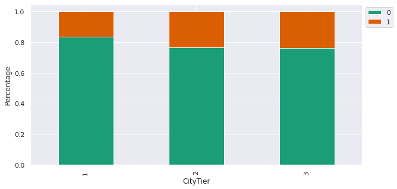

```python
stacked_plot(data_travel.CityTier)
```

- More Customers from Tier2 and Tier3 cities have purchased Travel Packages

```
ProdTaken          0    1   All
Occupation
Free Lancer        0    2     2
Large Business   314  120   434
Salaried        1954  414  2368
Small Business  1700  384  2084
All             3968  920  4888
------------------------------------------------------------------------------------------------------------------------
```

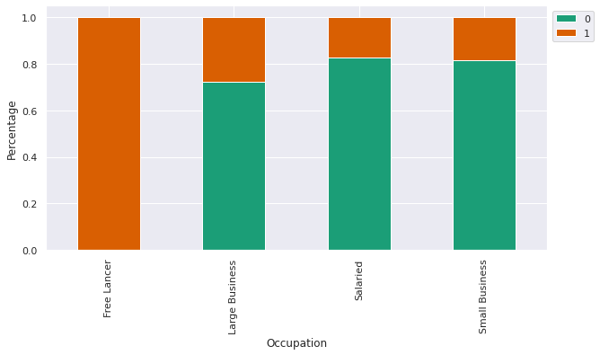

```python
stacked_plot(data_travel.Occupation)
```

- Though customers who are Freelancers by Occupation have bought travel packages, the sample size is only two.
- Of the 434 Large Business owning customers, almost 30% bought travel packages.
- Among Salaried and Small Business owning customers,close to 20% have bought travel packages

```
ProdTaken     0    1   All
Gender
Female     1630  342  1972
Male       2338  578  2916
All        3968  920  4888
------------------------------------------------------------------------------------------------------------------------
```

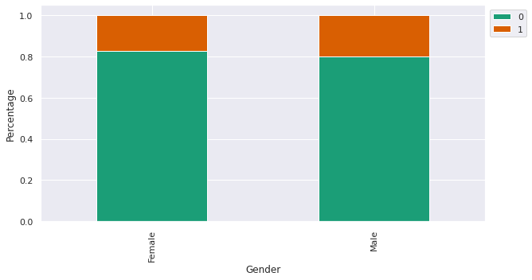

```python
stacked_plot(data_travel.Gender)
```

- Despite Male customers being significantly higher than Female customer, the percentage of those who bought travel packages is almost the same(or with minimum difference).

```
ProdTaken                  0    1   All
NumberOfPersonVisiting
1                         39    0    39
2                       1151  267  1418
3                       1942  460  2402
4                        833  193  1026
5                          3    0     3
All                     3968  920  4888
------------------------------------------------------------------------------------------------------------------------
```

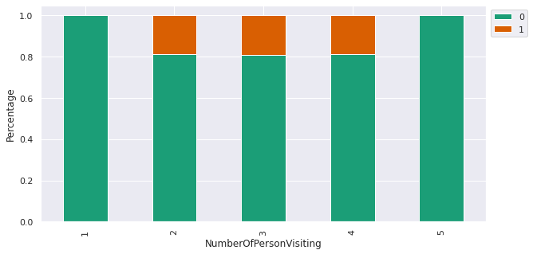

```python
stacked_plot(data_travel.NumberOfPersonVisiting)
```

- Among Customers who plan to take between 2-4 persons with them during travel, close to 20% have bought a travel package product.
- Interestingly, we see that all Customers with one companion and five comapanions, did not purchase any product.
- This suugests that the products dont seem either appealing or beneficial to the customers of the above two categories. This area needs further investigation

```
ProdTaken         0    1   All
MaritalStatus
Divorced        826  124   950
Married        2014  326  2340
Single          612  304   916
Unmarried       516  166   682
All            3968  920  4888
------------------------------------------------------------------------------------------------------------------------
```

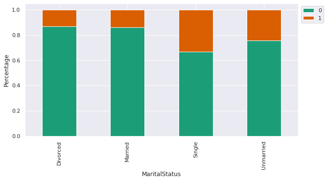

```python
stacked_plot(data_travel.MaritalStatus)
```

- Around 30% of all Single customers have bought a product and about 25% of Unmarried customers have also purchased a product
- Almost 50% of the total customers belong to the married category, but we see that only approx 15% of them have actually purchased any product.

```
ProdTaken                  0    1   All
PitchSatisfactionScore
1                        798  144   942
2                        498   88   586
3                       1162  316  1478
4                        750  162   912
5                        760  210   970
All                     3968  920  4888
------------------------------------------------------------------------------------------------------------------------
```

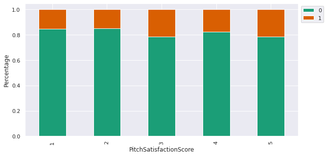

```python
stacked_plot(data_travel.PitchSatisfactionScore)
```

- Majority of customers have given a score of 3.0 to the Sale pitch for the products.
- But we observe that the number of customers who purchased any product is almost equal across all pitch scores.
- This suggests that a high product pitch score doesnt guarantee purchase

```
ProdTaken     0    1   All
Passport
0          3040  426  3466
1           928  494  1422
All        3968  920  4888
------------------------------------------------------------------------------------------------------------------------
```

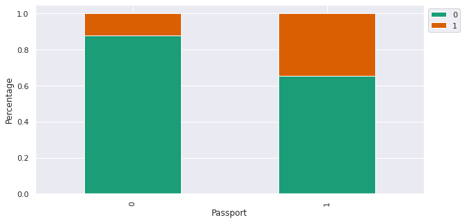

```python
stacked_plot(data_travel.Passport)
```

- More customers with passport tend to purchase products than those who dont.

```
ProdTaken                 0    1   All
PreferredPropertyStar
3.0                    2511  482  2993
4.0                     731  182   913
5.0                     706  250   956
All                    3948  914  4862
------------------------------------------------------------------------------------------------------------------------
```

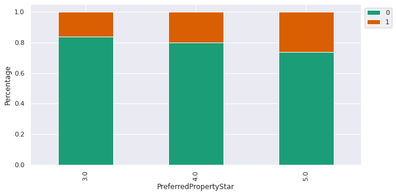

```python
stacked_plot(data_travel.PreferredPropertyStar)
```

- Though majority of customers prefer a 3.0 star rated Property, the percentage of customers purchasing the products is comparitively less than customers who prefer a 4.0 and 5.0 star rated property.
- The higher the proprety star rating, higher the number of customers who purchased a product

```
ProdTaken     0    1   All
OwnCar
0          1496  360  1856
1          2472  560  3032
All        3968  920  4888
------------------------------------------------------------------------------------------------------------------------
```

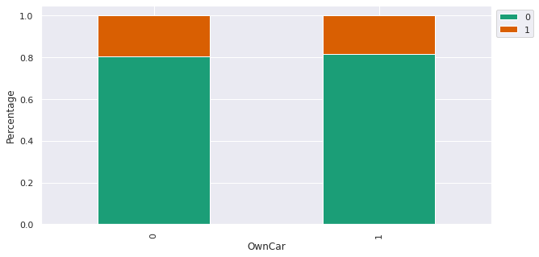

```python
stacked_plot(data_travel.OwnCar)
```

- The number of customers who bought a product is fairly equal across both classes of OwnCar

```
ProdTaken                    0    1   All
NumberOfChildrenVisiting
0.0                        880  202  1082
1.0                       1688  392  2080
2.0                       1082  253  1335
3.0                        259   66   325
All                       3909  913  4822
------------------------------------------------------------------------------------------------------------------------
```

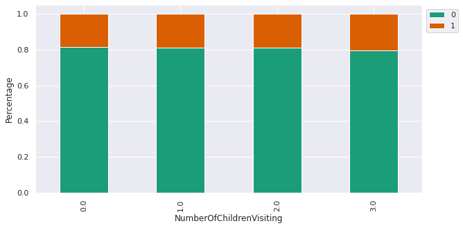

```python
stacked_plot(data_travel.NumberOfChildrenVisiting)
```

- We see that the percentage of customes who purchased a product is fairly same across all categories of variable NumberOfChildrenVisiting.

```
ProdTaken          0    1   All
ProductPitched
Basic           1290  552  1842
Deluxe          1528  204  1732
King             210   20   230
Standard         618  124   742
Super Deluxe     322   20   342
All             3968  920  4888
------------------------------------------------------------------------------------------------------------------------
```

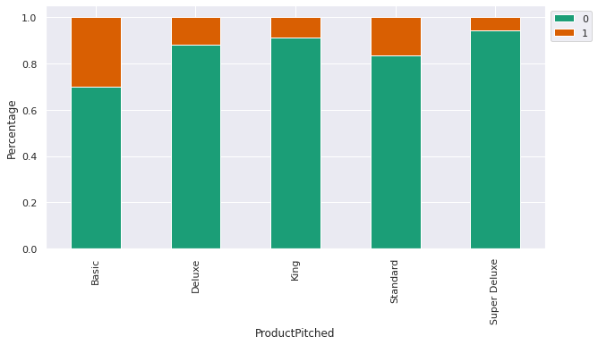

```python
stacked_plot(data_travel.ProductPitched)
```

- The Basic Package is the most preffered, with Standard and Deluxe following up.
- Comparitively very few customers purchased Super Deluxe products

```
ProdTaken          0    1   All
Designation
AVP              322   20   342
Executive       1290  552  1842
Manager         1528  204  1732
Senior Manager   618  124   742
VP               210   20   230
All             3968  920  4888
------------------------------------------------------------------------------------------------------------------------
```

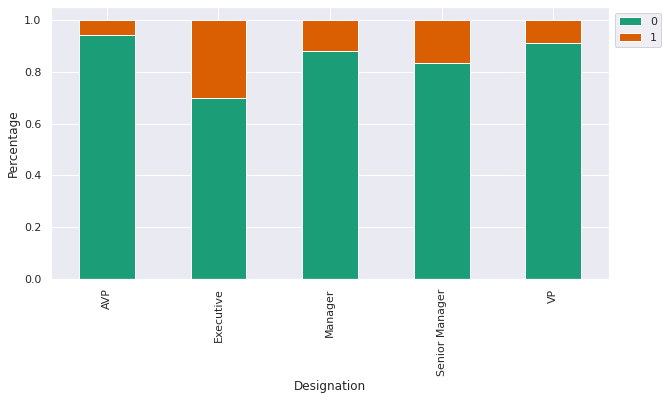

```python
stacked_plot(data_travel.Designation)
```

- Around 30% Customers with Executive Designation have purchased a product
- Sr. Manager(16%) and Manager(~11%) Designation customers have purchased a product.
- Very few customers of VP and AVP Designation have purchased a product.

## Missing Value Treatment:

```python
data_travel.isna().sum()
```

```
CustomerID                    0
ProdTaken                     0
Age                         226
TypeofContact                25
CityTier                      0
DurationOfPitch             251
Occupation                    0
Gender                        0
NumberOfPersonVisiting        0
NumberOfFollowups            45
ProductPitched                0
PreferredPropertyStar        26
MaritalStatus                 0
NumberOfTrips               140
Passport                      0
PitchSatisfactionScore        0
OwnCar                        0
NumberOfChildrenVisiting     66
Designation                   0
MonthlyIncome               233
Agebin                      240
Incomebin                   233
dtype: int64
```

#### Missing value Treatment Age

```python
data_travel[data_travel["Age"].isnull()].head(10)
```

|  | CustomerID | ProdTaken | Age | TypeofContact | CityTier | DurationOfPitch | Occupation | Gender | NumberOfPersonVisiting | NumberOfFollowups | ProductPitched | PreferredPropertyStar | MaritalStatus | NumberOfTrips | Passport | PitchSatisfactionScore | OwnCar | NumberOfChildrenVisiting | Designation | MonthlyIncome | Agebin | Incomebin |
| --- | --- | --- | --- | --- | --- | --- | --- | --- | --- | --- | --- | --- | --- | --- | --- | --- | --- | --- | --- | --- | --- | --- |
| 4 | 200004 | 0 | NaN | Self Enquiry | 1 | 8.0 | Small Business | Male | 2 | 3.0 | Basic | 4.0 | Divorced | 1.0 | 0 | 5 | 1 | 0.0 | Executive | 18468.0 | NaN | <20000 |
| 11 | 200011 | 0 | NaN | Self Enquiry | 1 | 21.0 | Salaried | Female | 2 | 4.0 | Deluxe | 3.0 | Single | 1.0 | 1 | 3 | 0 | 0.0 | Manager | NaN | NaN | NaN |
| 19 | 200019 | 0 | NaN | Self Enquiry | 1 | 8.0 | Salaried | Male | 2 | 3.0 | Basic | 3.0 | Single | 6.0 | 1 | 4 | 0 | 1.0 | Executive | NaN | NaN | NaN |
| 20 | 200020 | 0 | NaN | Company Invited | 1 | 17.0 | Salaried | Female | 3 | 2.0 | Deluxe | 3.0 | Married | 1.0 | 0 | 3 | 1 | 2.0 | Manager | NaN | NaN | NaN |
| 21 | 200021 | 1 | NaN | Self Enquiry | 3 | 15.0 | Salaried | Male | 2 | 4.0 | Deluxe | 5.0 | Single | 1.0 | 0 | 2 | 0 | 0.0 | Manager | 18407.0 | NaN | <20000 |
| 26 | 200026 | 1 | NaN | Company Invited | 1 | 22.0 | Salaried | Female | 3 | 5.0 | Basic | 5.0 | Single | 2.0 | 1 | 4 | 1 | 2.0 | Executive | NaN | NaN | NaN |
| 44 | 200044 | 0 | NaN | Company Invited | 1 | 6.0 | Small Business | Female | 2 | 3.0 | Deluxe | 3.0 | Single | 2.0 | 0 | 3 | 1 | 0.0 | Manager | NaN | NaN | NaN |
| 51 | 200051 | 1 | NaN | Self Enquiry | 1 | 11.0 | Large Business | Male | 2 | 3.0 | Basic | 3.0 | Single | 2.0 | 1 | 2 | 1 | 0.0 | Executive | 18441.0 | NaN | <20000 |
| 54 | 200054 | 0 | NaN | Self Enquiry | 3 | 29.0 | Small Business | Female | 2 | 4.0 | Deluxe | 3.0 | Divorced | 1.0 | 1 | 2 | 1 | 0.0 | Manager | NaN | NaN | NaN |
| 57 | 200057 | 0 | NaN | Self Enquiry | 1 | 29.0 | Small Business | Female | 1 | 3.0 | Basic | 5.0 | Divorced | 4.0 | 1 | 4 | 1 | 0.0 | Executive | NaN | NaN | NaN |

```python
data_travel.groupby(["Designation", "Gender","MaritalStatus"])["Age"].median()

# Impute missing Age with median value
data_travel["Age"] = data_travel.groupby(["Designation", "Gender","MaritalStatus"])["Age"].apply(
    lambda x: x.fillna(x.median())
)
```

#### Missing value Treatment MonthlyIncome

```python
data_travel.groupby(["Occupation",'Designation','Gender'])["MonthlyIncome"].median()
```

```
Occupation      Designation     Gender
Free Lancer     AVP             Female        NaN
                                Male          NaN
                Executive       Female        NaN
                                Male      18929.0
                Manager         Female        NaN
                                Male          NaN
                Senior Manager  Female        NaN
                                Male          NaN
                VP              Female        NaN
                                Male          NaN
Large Business  AVP             Female    31872.0
                                Male      29959.0
                Executive       Female    20748.0
                                Male      20743.5
                Manager         Female    22198.5
                                Male      21997.0
                Senior Manager  Female    28266.0
                                Male      26838.5
                VP              Female    36583.0
                                Male      36071.0
Salaried        AVP             Female    31890.0
                                Male      32505.5
                Executive       Female    20748.0
                                Male      20371.5
                Manager         Female    22826.0
                                Male      22873.5
                Senior Manager  Female    26713.0
                                Male      26052.5
                VP              Female    35846.0
                                Male      35971.0
Small Business  AVP             Female    32171.5
                                Male      32386.0
                Executive       Female    20685.0
                                Male      20582.0
                Manager         Female    23071.0
                                Male      22984.0
                Senior Manager  Female    26383.5
                                Male      26297.0
                VP              Female    34845.0
                                Male      35868.5
Name: MonthlyIncome, dtype: float64
```

```python
data_travel["MonthlyIncome"]=data_travel.groupby(["Occupation",'Designation','Gender'])["MonthlyIncome"].apply(
    lambda x: x.fillna(x.median())
)
```

#### Missing value Treatment NumberOfChildrenVisiting

```python
data_travel[data_travel["NumberOfChildrenVisiting"].isnull()].head(10)
```

|  | CustomerID | ProdTaken | Age | TypeofContact | CityTier | DurationOfPitch | Occupation | Gender | NumberOfPersonVisiting | NumberOfFollowups | ProductPitched | PreferredPropertyStar | MaritalStatus | NumberOfTrips | Passport | PitchSatisfactionScore | OwnCar | NumberOfChildrenVisiting | Designation | MonthlyIncome | Agebin | Incomebin |
| --- | --- | --- | --- | --- | --- | --- | --- | --- | --- | --- | --- | --- | --- | --- | --- | --- | --- | --- | --- | --- | --- | --- |
| 165 | 200165 | 0 | 50.0 | Self Enquiry | 1 | 17.0 | Salaried | Female | 2 | 3.0 | King | 4.0 | Single | 4.0 | 0 | 5 | 1 | NaN | VP | 34926.0 | 41-50 | <35000 |
| 190 | 200190 | 0 | 52.0 | Self Enquiry | 1 | 6.0 | Salaried | Male | 3 | 4.0 | King | 3.0 | Divorced | 1.0 | 0 | 2 | 1 | NaN | VP | 34999.0 | 51-65 | <35000 |
| 568 | 200568 | 1 | 55.0 | Self Enquiry | 1 | 8.0 | Small Business | Male | 3 | 3.0 | King | 5.0 | Divorced | 6.0 | 1 | 2 | 1 | NaN | VP | 34859.0 | 51-65 | <35000 |
| 746 | 200746 | 0 | 41.0 | Company Invited | 1 | 13.0 | Salaried | Female | 2 | 5.0 | King | 3.0 | Married | 2.0 | 0 | 4 | 1 | NaN | VP | 34973.0 | 41-50 | <35000 |
| 749 | 200749 | 1 | 52.0 | Self Enquiry | 3 | 8.0 | Small Business | Female | 2 | 5.0 | King | 3.0 | Divorced | 2.0 | 0 | 3 | 1 | NaN | VP | 34845.0 | 51-65 | <35000 |
| 851 | 200851 | 0 | 56.0 | Self Enquiry | 1 | 10.0 | Large Business | Female | 3 | 3.0 | King | 5.0 | Married | 5.0 | 0 | 4 | 0 | NaN | VP | 34943.0 | 51-65 | <35000 |
| 898 | 200898 | 0 | 43.0 | Self Enquiry | 1 | 9.0 | Salaried | Male | 3 | 5.0 | King | 3.0 | Divorced | 4.0 | 0 | 5 | 1 | NaN | VP | 34740.0 | 41-50 | <35000 |
| 918 | 200918 | 0 | 51.0 | Company Invited | 3 | 15.0 | Salaried | Male | 2 | 3.0 | King | 4.0 | Married | 5.0 | 1 | 4 | 1 | NaN | VP | 34847.0 | 51-65 | <35000 |
| 956 | 200956 | 0 | 56.0 | Self Enquiry | 2 | 14.0 | Salaried | Male | 2 | 3.0 | King | 4.0 | Single | 7.0 | 0 | 4 | 1 | NaN | VP | 34717.0 | 51-65 | <35000 |
| 1009 | 201009 | 0 | 58.0 | Self Enquiry | 1 | 6.0 | Small Business | Female | 3 | 3.0 | King | 5.0 | Divorced | 4.0 | 1 | 1 | 1 | NaN | VP | 34701.0 | 51-65 | <35000 |

```python
#Assuming  children visited is missing because no children accompanied these customers so we will fill the missing values with 0
# Impute missing NumberOfChildrenVisited with 0
data_travel['NumberOfChildrenVisiting']=data_travel['NumberOfChildrenVisiting'].fillna(0)
```

#### Missing value Treatment Type of contact

```python
data_travel['TypeofContact'].value_counts()
```

```
Self Enquiry       3444
Company Invited    1419
Name: TypeofContact, dtype: int64
```

```python
#Highest ocurring value is `Self Inquiry`. We will impute the missing value for TypeofContact using the mode(highest occuring value) of the feature.
data_travel['TypeofContact'].mode()

data_travel['TypeofContact']=data_travel['TypeofContact'].fillna('Self Enquiry')
```

#### Missing value Treatment number of followups

```python
data_travel.groupby(["Gender",'ProductPitched'])["NumberOfFollowups"].median()

data_travel['NumberOfFollowups']=data_travel.groupby(["Gender",'ProductPitched'])["NumberOfFollowups"].apply(lambda x:x.fillna(x.median()))
```

#### Missing value Treatment PreferredPropertyStar

```python
#Look at few rows where values  is missing
data_travel[data_travel["PreferredPropertyStar"].isnull()]
```

|  | CustomerID | ProdTaken | Age | TypeofContact | CityTier | DurationOfPitch | Occupation | Gender | NumberOfPersonVisiting | NumberOfFollowups | ProductPitched | PreferredPropertyStar | MaritalStatus | NumberOfTrips | Passport | PitchSatisfactionScore | OwnCar | NumberOfChildrenVisiting | Designation | MonthlyIncome | Agebin | Incomebin |
| --- | --- | --- | --- | --- | --- | --- | --- | --- | --- | --- | --- | --- | --- | --- | --- | --- | --- | --- | --- | --- | --- | --- |
| 38 | 200038 | 0 | 36.0 | Self Enquiry | 1 | 11.0 | Salaried | Female | 2 | 4.0 | Basic | NaN | Divorced | 1.0 | 1 | 2 | 1 | 0.0 | Executive | 95000.0 | 31-40 | <100000 |
| 2609 | 202609 | 0 | 51.0 | Self Enquiry | 1 | 18.0 | Salaried | Female | 3 | 4.0 | King | NaN | Single | 5.0 | 0 | 5 | 1 | 1.0 | VP | 38604.0 | 51-65 | <40000 |
| 2634 | 202634 | 0 | 53.0 | Self Enquiry | 1 | 7.0 | Salaried | Male | 4 | 5.0 | King | NaN | Divorced | 2.0 | 0 | 2 | 1 | 2.0 | VP | 38677.0 | 51-65 | <40000 |
| 3012 | 203012 | 1 | 56.0 | Self Enquiry | 1 | 9.0 | Small Business | Male | 4 | 4.0 | King | NaN | Divorced | 7.0 | 1 | 2 | 1 | 3.0 | VP | 38537.0 | 51-65 | <40000 |
| 3190 | 203190 | 0 | 42.0 | Company Invited | 1 | 14.0 | Salaried | Female | 3 | 6.0 | King | NaN | Married | 3.0 | 0 | 4 | 1 | 1.0 | VP | 38651.0 | 41-50 | <40000 |
| 3193 | 203193 | 1 | 53.0 | Self Enquiry | 3 | 9.0 | Small Business | Female | 3 | 6.0 | King | NaN | Divorced | 3.0 | 0 | 3 | 1 | 1.0 | VP | 38523.0 | 51-65 | <40000 |
| 3214 | 203214 | 0 | 47.0 | Self Enquiry | 1 | 7.0 | Small Business | Male | 3 | 4.0 | King | NaN | Married | 2.0 | 0 | 5 | 1 | 2.0 | VP | 38305.0 | 41-50 | <40000 |
| 3295 | 203295 | 0 | 57.0 | Self Enquiry | 1 | 11.0 | Large Business | Female | 4 | 4.0 | King | NaN | Married | 6.0 | 0 | 4 | 0 | 3.0 | VP | 38621.0 | 51-65 | <40000 |
| 3342 | 203342 | 0 | 44.0 | Self Enquiry | 1 | 10.0 | Salaried | Male | 4 | 6.0 | King | NaN | Divorced | 5.0 | 0 | 5 | 1 | 3.0 | VP | 38418.0 | 41-50 | <40000 |
| 3362 | 203362 | 0 | 52.0 | Company Invited | 3 | 16.0 | Salaried | Male | 3 | 4.0 | King | NaN | Married | 6.0 | 1 | 4 | 1 | 2.0 | VP | 38525.0 | 51-65 | <40000 |
| 3400 | 203400 | 0 | 57.0 | Self Enquiry | 2 | 15.0 | Salaried | Male | 3 | 4.0 | King | NaN | Single | 8.0 | 0 | 4 | 1 | 1.0 | VP | 38395.0 | 51-65 | <40000 |
| 3453 | 203453 | 0 | 59.0 | Self Enquiry | 1 | 7.0 | Small Business | Female | 4 | 4.0 | King | NaN | Divorced | 5.0 | 1 | 1 | 1 | 3.0 | VP | 38379.0 | 51-65 | <40000 |
| 3598 | 203598 | 0 | 48.0 | Self Enquiry | 2 | 33.0 | Salaried | Female | 4 | 4.0 | King | NaN | Married | 5.0 | 0 | 4 | 1 | 2.0 | VP | 38336.0 | 41-50 | <40000 |
| 3686 | 203686 | 0 | 41.0 | Self Enquiry | 3 | 14.0 | Small Business | Male | 3 | 4.0 | King | NaN | Single | 3.0 | 0 | 4 | 1 | 2.0 | VP | 38511.0 | 41-50 | <40000 |
| 3775 | 203775 | 0 | 49.0 | Self Enquiry | 1 | 17.0 | Salaried | Male | 4 | 5.0 | King | NaN | Married | 6.0 | 0 | 3 | 1 | 2.0 | VP | 38343.0 | 41-50 | <40000 |
| 3845 | 203845 | 0 | 56.0 | Self Enquiry | 2 | 33.0 | Salaried | Male | 4 | 2.0 | King | NaN | Married | 6.0 | 1 | 5 | 1 | 3.0 | VP | 38314.0 | 51-65 | <40000 |
| 4079 | 204079 | 0 | 51.0 | Self Enquiry | 1 | 18.0 | Salaried | Female | 3 | 4.0 | King | NaN | Single | 5.0 | 0 | 5 | 0 | 2.0 | VP | 38604.0 | 51-65 | <40000 |
| 4104 | 204104 | 0 | 53.0 | Self Enquiry | 1 | 7.0 | Salaried | Male | 4 | 5.0 | King | NaN | Married | 2.0 | 0 | 1 | 1 | 3.0 | VP | 38677.0 | 51-65 | <40000 |
| 4482 | 204482 | 1 | 56.0 | Self Enquiry | 1 | 9.0 | Small Business | Male | 4 | 4.0 | King | NaN | Married | 7.0 | 1 | 1 | 1 | 1.0 | VP | 38537.0 | 51-65 | <40000 |
| 4660 | 204660 | 0 | 42.0 | Company Invited | 1 | 14.0 | Salaried | Female | 3 | 6.0 | King | NaN | Married | 3.0 | 0 | 4 | 1 | 2.0 | VP | 38651.0 | 41-50 | <40000 |
| 4663 | 204663 | 1 | 53.0 | Self Enquiry | 3 | 9.0 | Small Business | Female | 3 | 6.0 | King | NaN | Married | 3.0 | 0 | 3 | 1 | 2.0 | VP | 38523.0 | 51-65 | <40000 |
| 4684 | 204684 | 0 | 47.0 | Self Enquiry | 1 | 7.0 | Small Business | Male | 3 | 4.0 | King | NaN | Married | 2.0 | 0 | 5 | 1 | 1.0 | VP | 38305.0 | 41-50 | <40000 |
| 4765 | 204765 | 0 | 57.0 | Self Enquiry | 1 | 11.0 | Large Business | Female | 4 | 4.0 | King | NaN | Married | 6.0 | 0 | 4 | 1 | 2.0 | VP | 38621.0 | 51-65 | <40000 |
| 4812 | 204812 | 0 | 44.0 | Self Enquiry | 1 | 10.0 | Salaried | Male | 4 | 6.0 | King | NaN | Married | 5.0 | 0 | 5 | 1 | 1.0 | VP | 38418.0 | 41-50 | <40000 |
| 4832 | 204832 | 1 | 52.0 | Company Invited | 1 | 35.0 | Salaried | Male | 4 | 5.0 | Deluxe | NaN | Single | 5.0 | 0 | 3 | 0 | 1.0 | Manager | 38525.0 | 51-65 | <40000 |
| 4870 | 204870 | 1 | 57.0 | Self Enquiry | 3 | 23.0 | Salaried | Female | 4 | 4.0 | Standard | NaN | Single | 4.0 | 1 | 5 | 1 | 3.0 | Senior Manager | 38395.0 | 51-65 | <40000 |

```python
#Let see how can impute PreferredPropertyStar using  designation  of customer for more granularity
```

```python
data_travel['PreferredPropertyStar']=data_travel.groupby(["Designation"])["PreferredPropertyStar"].apply(lambda x:x.fillna(x.median()))

data_travel[data_travel["PreferredPropertyStar"].isnull()]
```

|  | CustomerID | ProdTaken | Age | TypeofContact | CityTier | DurationOfPitch | Occupation | Gender | NumberOfPersonVisiting | NumberOfFollowups | ProductPitched | PreferredPropertyStar | MaritalStatus | NumberOfTrips | Passport | PitchSatisfactionScore | OwnCar | NumberOfChildrenVisiting | Designation | MonthlyIncome | Agebin | Incomebin |
| --- | --- | --- | --- | --- | --- | --- | --- | --- | --- | --- | --- | --- | --- | --- | --- | --- | --- | --- | --- | --- | --- | --- |

#### Missing value Treatment Duration of pitch

```python
#Let see how can we impute Duration of pitch.In my opinion an important factor for how long sale person take times to market his sales pitch depends on Product which sale person is proposing , number of followup will also decide duration of pitch. Let verify this.
data_travel.groupby(['ProductPitched','NumberOfFollowups'], as_index=False)["DurationOfPitch"].median()

# Impute missing Duration of pitch with median value
data_travel["DurationOfPitch"] = data_travel.groupby(["ProductPitched",'NumberOfFollowups'])["DurationOfPitch"].apply(
    lambda x: x.fillna(x.median())
)
```

```python
data_travel[data_travel["DurationOfPitch"].isnull()]

data_travel.isnull().sum()
```

```
CustomerID                    0
ProdTaken                     0
Age                           0
TypeofContact                 0
CityTier                      0
DurationOfPitch               0
Occupation                    0
Gender                        0
NumberOfPersonVisiting        0
NumberOfFollowups             0
ProductPitched                0
PreferredPropertyStar         0
MaritalStatus                 0
NumberOfTrips               140
Passport                      0
PitchSatisfactionScore        0
OwnCar                        0
NumberOfChildrenVisiting      0
Designation                   0
MonthlyIncome                 0
Agebin                      240
Incomebin                   233
dtype: int64
```

#### Missing value Treatment for NumberOfTrips

```python
data_travel.groupby(['MaritalStatus'])["NumberOfTrips"].median()
```

```
MaritalStatus
Divorced     3.0
Married      3.0
Single       2.0
Unmarried    3.0
Name: NumberOfTrips, dtype: float64
```

```python
# Impute missing NumberOfTrips of pitch with median value
data_travel["NumberOfTrips"] = data_travel.groupby(["MaritalStatus"])["NumberOfTrips"].apply(
    lambda x: x.fillna(x.median())
)
```

#### Missing value Treatment for Age

```python
data_travel.Age.describe()
```

```
count    4888.000000
mean       37.413564
std         9.162798
min        18.000000
25%        31.000000
50%        36.000000
75%        43.000000
max        61.000000
Name: Age, dtype: float64
```

```python
data_travel['Agebin'] = pd.cut(data_travel['Age'], bins = [15,25, 31, 40, 50, 70], labels = ['15-25','26-30', '31-40', '41-50', '51-70'])
```

```python
data_travel.Agebin.value_counts()
```

```
31-40    1894
41-50    1073
26-30    1025
51-70     549
15-25     347
Name: Agebin, dtype: int64
```

#### Missing value Treatment for Income

```python
data_travel.MonthlyIncome.describe()
```

```
count     4888.000000
mean     23543.855769
std       5267.651455
min       1000.000000
25%      20438.250000
50%      22393.000000
75%      25424.750000
max      98678.000000
Name: MonthlyIncome, dtype: float64
```

```python
data_travel['Incomebin'] = pd.cut(data_travel['MonthlyIncome'], bins = [0,15000,20000, 25000, 30000,35000,40000,45000,50000,100000], labels = ['<15000', '<20000', '<25000', '<30000','<35000','<40000','<45000','<50000','<100000'])
```

```python
data_travel.Incomebin.value_counts()
```

```
<25000     2490
<20000     1038
<30000      768
<35000      382
<40000      206
<15000        2
<100000       2
<45000        0
<50000        0
Name: Incomebin, dtype: int64
```

```python
data_travel.isnull().sum()
```

```
CustomerID                  0
ProdTaken                   0
Age                         0
TypeofContact               0
CityTier                    0
DurationOfPitch             0
Occupation                  0
Gender                      0
NumberOfPersonVisiting      0
NumberOfFollowups           0
ProductPitched              0
PreferredPropertyStar       0
MaritalStatus               0
NumberOfTrips               0
Passport                    0
PitchSatisfactionScore      0
OwnCar                      0
NumberOfChildrenVisiting    0
Designation                 0
MonthlyIncome               0
Agebin                      0
Incomebin                   0
dtype: int64
```

## Outlier Detection

```python
Q1 = data_travel.quantile(0.25)             #To find the 25th percentile and 75th percentile.
Q3 = data_travel.quantile(0.75)

IQR = Q3 - Q1                           #Inter Quantile Range (75th perentile - 25th percentile)

lower=Q1-1.5*IQR                        #Finding lower and upper bounds for all values. All values outside these bounds are outliers
upper=Q3+1.5*IQR
```

```python
((data_travel.select_dtypes(include=['float64','int64'])<lower) | (data_travel.select_dtypes(include=['float64','int64'])>upper)).sum()/len(data_travel)*100
```

```
CustomerID                  0.000000
Age                         0.000000
DurationOfPitch             2.291326
NumberOfPersonVisiting      0.061375
NumberOfFollowups           6.382979
PreferredPropertyStar       0.000000
NumberOfTrips               2.229951
PitchSatisfactionScore      0.000000
NumberOfChildrenVisiting    0.000000
MonthlyIncome               7.528642
dtype: float64
```

Since customer interaction data will not be available for potential customers and new customers,outliers in Number of trips and Monthly Income needs to be handled

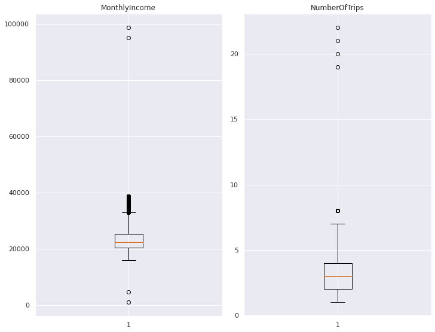

```python
numeric_columns = ['MonthlyIncome','NumberOfTrips']
# outlier detection using boxplot
plt.figure(figsize=(20,30))

for i, variable in enumerate(numeric_columns):
                     plt.subplot(4,4,i+1)
                     plt.boxplot(data_travel[variable],whis=1.5)
                     plt.tight_layout()
                     plt.title(variable)

plt.show()
```

```python
# Check MonthlyIncome extreme values
data_travel.sort_values(by=["MonthlyIncome"],ascending = False).head(15)
```

|  | CustomerID | ProdTaken | Age | TypeofContact | CityTier | DurationOfPitch | Occupation | Gender | NumberOfPersonVisiting | NumberOfFollowups | ProductPitched | PreferredPropertyStar | MaritalStatus | NumberOfTrips | Passport | PitchSatisfactionScore | OwnCar | NumberOfChildrenVisiting | Designation | MonthlyIncome | Agebin | Incomebin |
| --- | --- | --- | --- | --- | --- | --- | --- | --- | --- | --- | --- | --- | --- | --- | --- | --- | --- | --- | --- | --- | --- | --- |
| 2482 | 202482 | 0 | 37.0 | Self Enquiry | 1 | 12.0 | Salaried | Female | 3 | 5.0 | Basic | 5.0 | Divorced | 2.0 | 1 | 2 | 1 | 1.0 | Executive | 98678.0 | 31-40 | <100000 |
| 38 | 200038 | 0 | 36.0 | Self Enquiry | 1 | 11.0 | Salaried | Female | 2 | 4.0 | Basic | 3.0 | Divorced | 1.0 | 1 | 2 | 1 | 0.0 | Executive | 95000.0 | 31-40 | <100000 |
| 2634 | 202634 | 0 | 53.0 | Self Enquiry | 1 | 7.0 | Salaried | Male | 4 | 5.0 | King | 3.0 | Divorced | 2.0 | 0 | 2 | 1 | 2.0 | VP | 38677.0 | 51-70 | <40000 |
| 4104 | 204104 | 0 | 53.0 | Self Enquiry | 1 | 7.0 | Salaried | Male | 4 | 5.0 | King | 3.0 | Married | 2.0 | 0 | 1 | 1 | 3.0 | VP | 38677.0 | 51-70 | <40000 |
| 3190 | 203190 | 0 | 42.0 | Company Invited | 1 | 14.0 | Salaried | Female | 3 | 6.0 | King | 3.0 | Married | 3.0 | 0 | 4 | 1 | 1.0 | VP | 38651.0 | 41-50 | <40000 |
| 4660 | 204660 | 0 | 42.0 | Company Invited | 1 | 14.0 | Salaried | Female | 3 | 6.0 | King | 3.0 | Married | 3.0 | 0 | 4 | 1 | 2.0 | VP | 38651.0 | 41-50 | <40000 |
| 3295 | 203295 | 0 | 57.0 | Self Enquiry | 1 | 11.0 | Large Business | Female | 4 | 4.0 | King | 3.0 | Married | 6.0 | 0 | 4 | 0 | 3.0 | VP | 38621.0 | 51-70 | <40000 |
| 4765 | 204765 | 0 | 57.0 | Self Enquiry | 1 | 11.0 | Large Business | Female | 4 | 4.0 | King | 3.0 | Married | 6.0 | 0 | 4 | 1 | 2.0 | VP | 38621.0 | 51-70 | <40000 |
| 4079 | 204079 | 0 | 51.0 | Self Enquiry | 1 | 18.0 | Salaried | Female | 3 | 4.0 | King | 3.0 | Single | 5.0 | 0 | 5 | 0 | 2.0 | VP | 38604.0 | 51-70 | <40000 |
| 2609 | 202609 | 0 | 51.0 | Self Enquiry | 1 | 18.0 | Salaried | Female | 3 | 4.0 | King | 3.0 | Single | 5.0 | 0 | 5 | 1 | 1.0 | VP | 38604.0 | 51-70 | <40000 |
| 4482 | 204482 | 1 | 56.0 | Self Enquiry | 1 | 9.0 | Small Business | Male | 4 | 4.0 | King | 3.0 | Married | 7.0 | 1 | 1 | 1 | 1.0 | VP | 38537.0 | 51-70 | <40000 |
| 3012 | 203012 | 1 | 56.0 | Self Enquiry | 1 | 9.0 | Small Business | Male | 4 | 4.0 | King | 3.0 | Divorced | 7.0 | 1 | 2 | 1 | 3.0 | VP | 38537.0 | 51-70 | <40000 |
| 4832 | 204832 | 1 | 52.0 | Company Invited | 1 | 35.0 | Salaried | Male | 4 | 5.0 | Deluxe | 3.0 | Single | 5.0 | 0 | 3 | 0 | 1.0 | Manager | 38525.0 | 51-70 | <40000 |
| 3362 | 203362 | 0 | 52.0 | Company Invited | 3 | 16.0 | Salaried | Male | 3 | 4.0 | King | 3.0 | Married | 6.0 | 1 | 4 | 1 | 2.0 | VP | 38525.0 | 51-70 | <40000 |
| 4663 | 204663 | 1 | 53.0 | Self Enquiry | 3 | 9.0 | Small Business | Female | 3 | 6.0 | King | 3.0 | Married | 3.0 | 0 | 3 | 1 | 2.0 | VP | 38523.0 | 51-70 | <40000 |